# WB PD5 Szymon Rećko

```python
import json
from keras.applications import VGG19
import keras
import numpy as np
import pandas as pd
from keras.applications.vgg19 import preprocess_input,decode_predictions
from matplotlib.image import imread
from matplotlib.pyplot import imshow
from keras.models import Model
import tensorflow as tf
import matplotlib.pyplot as plt
import matplotlib.cm as cm
from IPython.display import Image, display
import math
from typing import Dict, Optional
from lime import lime_image
from lime.wrappers.scikit_image import SegmentationAlgorithm
from skimage.segmentation import mark_boundaries
from keras.engine.training import Model
```

## VGG19

VGG19(https://arxiv.org/abs/1409.1556) jest jednym z wariantów modelu VGG, który składa się z 19 warstw (stąd nazwa). Jego celem jest klasyfikakcja obrazów za pomocą jednego z 1000 labeli. Sieć przyjmuje na wejściu obrazki RGB o wielkości 224x224. Warstwy konwolucyjne posiadają filtry wielkości 3x3 i stride=1, a max pooling działa na 'okienkach' wielkości 2x2 i posiada stride=2. Model którego będzimy używać został już wytrenowany na zbiorze ImageNet(https://www.image-net.org/).(Źródło obrazka:https://www.researchgate.net/figure/Architecture-of-the-FCN-VGG19-adapted-from-Long-et-al-2015-which-learns-to-combine_fig1_331258180)

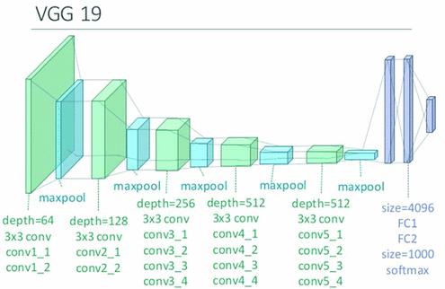

```python
keras.preprocessing.image.load_img("VGG19arch.gif")
```

```python
model=VGG19()
```

## Zdjęcia

Obrazki pochodzą z tej strony https://www.gettyimages.com/photos/labrador-retriever?phrase=labrador%20retriever&sort=mostpopular

## GRAD-CAM

Kod poniższych funkcji został stworzyony przez François Chollet'a i można znaleźć go np. tu https://keras.io/examples/vision/grad_cam/. Ja wprowadziłem tylko kilka zmian. Artykuł opisujący GRAD-CAM: https://arxiv.org/pdf/1610.02391.pdf

```python
def make_gradcam_heatmap(img_array, model, last_conv_layer_name, pred_index=None):
    grad_model = Model(
        [model.inputs], [model.get_layer(last_conv_layer_name).output, model.output]
    )
    with tf.GradientTape() as tape:
        last_conv_layer_output, preds = grad_model(img_array)
        if pred_index is None:
            pred_index = tf.argmax(preds[0])
        class_channel = preds[:, pred_index]
    grads = tape.gradient(class_channel, last_conv_layer_output)
    pooled_grads = tf.reduce_mean(grads, axis=(0, 1, 2))
    last_conv_layer_output = last_conv_layer_output[0]
    heatmap = last_conv_layer_output @ pooled_grads[..., tf.newaxis]
    heatmap = tf.squeeze(heatmap)
    heatmap = tf.maximum(heatmap, 0) / tf.math.reduce_max(heatmap)
    return heatmap.numpy()
```

```python
def save_and_display_gradcam(img_path, heatmap, cam_path="cam.jpg", alpha=0.4):
    img = keras.preprocessing.image.load_img(img_path)
    img = keras.preprocessing.image.img_to_array(img)
    heatmap = np.uint8(255 * heatmap)
    jet = cm.get_cmap("jet")
    jet_colors = jet(np.arange(256))[:, :3]
    jet_heatmap = jet_colors[heatmap]
    jet_heatmap = keras.preprocessing.image.array_to_img(jet_heatmap)
    jet_heatmap = jet_heatmap.resize((img.shape[1], img.shape[0]))
    jet_heatmap = keras.preprocessing.image.img_to_array(jet_heatmap)
    superimposed_img = jet_heatmap * alpha + img
    superimposed_img = keras.preprocessing.image.array_to_img(superimposed_img)
    superimposed_img.save(cam_path)
    display(Image(cam_path))
def get_img_array(img_path):
    img = keras.preprocessing.image.load_img(img_path, target_size=(224,224))
    array = keras.preprocessing.image.img_to_array(img)
    array = np.expand_dims(array, axis=0)
    preprocess_input(array)
    return array
```

Stworzona przeze mnie funkcja do wyświetlania efektów.

```python
def GradCAM(img_path):
    img=get_img_array(img_path)
    for name,clas,prob in decode_predictions(model.predict(img),top=3)[0]:
        print("{:.2f}".format(prob*100),"% ",clas)
    heatmap = make_gradcam_heatmap(img, model, "block5_conv4")
    save_and_display_gradcam(img_path, heatmap)
```

```
67.00 %  Labrador_retriever
6.93 %  kuvasz
3.93 %  golden_retriever
```

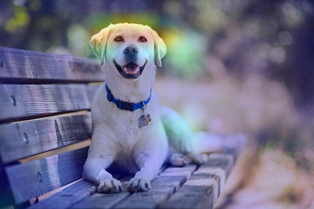

```python
GradCAM("labrador1.jpg")
```

```
80.25 %  Bedlington_terrier
4.91 %  standard_poodle
3.99 %  English_setter
```

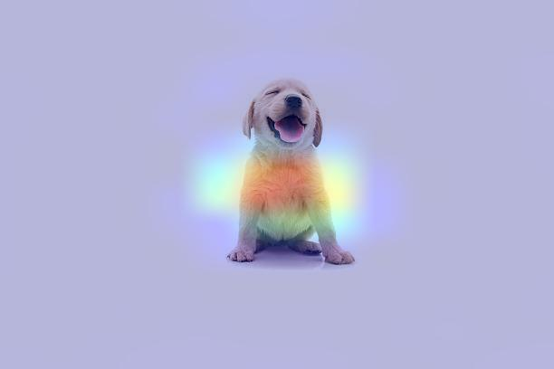

```python
GradCAM("labrador2.jpg")
```

```
67.59 %  Labrador_retriever
14.26 %  Chesapeake_Bay_retriever
4.37 %  Great_Dane
```

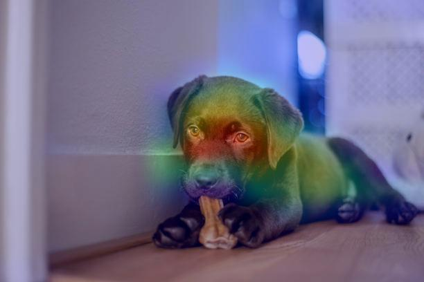

```python
GradCAM("labrador3.jpg")
```

```
68.48 %  Labrador_retriever
6.35 %  Saluki
4.35 %  kuvasz
```

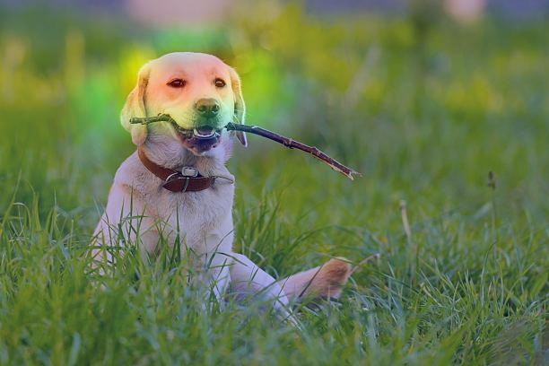

```python
GradCAM("labrador4.jpg")
```

```
81.80 %  Labrador_retriever
11.51 %  flat-coated_retriever
3.86 %  German_short-haired_pointer
```

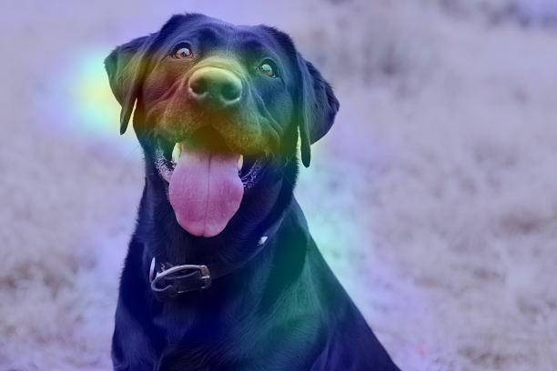

```python
GradCAM("labrador5.jpg")
```

```
42.65 %  Labrador_retriever
38.11 %  flat-coated_retriever
10.54 %  Chesapeake_Bay_retriever
```

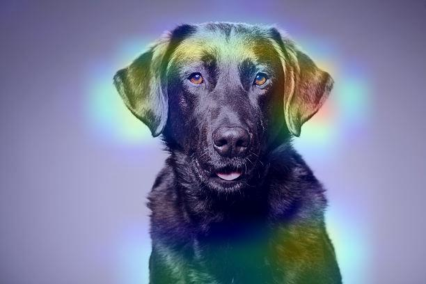

```python
GradCAM("labrador6.jpg")
```

```
43.94 %  Bedlington_terrier
23.15 %  English_setter
9.40 %  Saluki
```

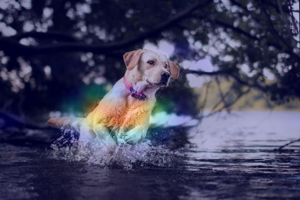

```python
GradCAM("labrador7.jpg")
```

```
40.33 %  Great_Dane
20.38 %  whippet
4.11 %  Irish_wolfhound
```

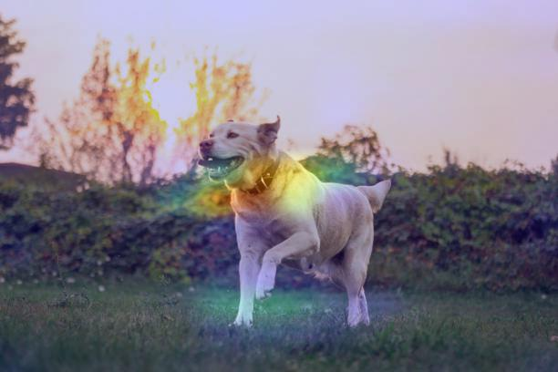

```python
GradCAM("labrador8.jpg")
```

## LIME

Kod poniżej jest mocno inspirowany tym notebookiem https://github.com/SkalskiP/ILearnDeepLearning.py/blob/master/02_data_science_toolkit/03_explaining_image_classifier_predictions/01_coco_res_net/coco-resnet-keras-resnet-34-lime.ipynb. Artykuł opisujący LIME: https://arxiv.org/pdf/1602.04938.pdf

```python
def get_class_names() -> Dict[int, str]:
    url = "imagenet_class_index.json"
    with open(url) as f:
        return {int(k): v[1] for k, v in json.load(f).items()}
```

```python
def plot_lime_top_explanations(model, img_path):
    img_array = keras.preprocessing.image.load_img(img_path,target_size=(224,224))
    img_array = keras.preprocessing.image.img_to_array(img_array).astype('double')
    fig_name="LIME"
    top_preds_count = 3
    image_columns = 3
    image_rows = math.ceil(top_preds_count / image_columns)

    explainer = lime_image.LimeImageExplainer(verbose = False)
    explanation = explainer.explain_instance(
        img_array,
        classifier_fn = model.predict,
        top_labels=3,
        hide_color=0,
        num_samples=1000
    )

    preds = model.predict(np.expand_dims(img_array, axis=0))
    top_preds_indexes = np.flip(np.argsort(preds))[0,:top_preds_count]
    top_preds_values = preds.take(top_preds_indexes)
    labels = decode_predictions(preds)[0]

    plt.style.use('dark_background')
    fig, axes = plt.subplots(image_rows, image_columns, figsize=(image_columns * 5, image_rows * 5))
    [ax.set_axis_off() for ax in axes.flat]

    for i, (index, value, name, ax) in \
        enumerate(zip(top_preds_indexes, top_preds_values, labels, axes.flat)):

        temp, mask = explanation.get_image_and_mask(
            explanation.top_labels[i],
            positive_only=False,
            num_features=5,
            hide_rest=False
        )

        subplot_title = "{}. class: {} pred: {:.3f}".format(i + 1, name[1], value)
        ax.imshow(mark_boundaries(temp / 255, mask))
        ax.set_title(subplot_title, pad=20)


    if fig_name:
        plt.savefig(fig_name)
    plt.show()
```

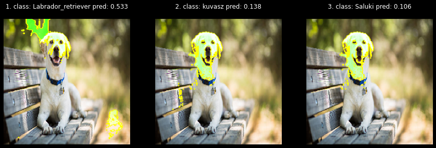

```python
plot_lime_top_explanations(model, "labrador1.jpg")
```

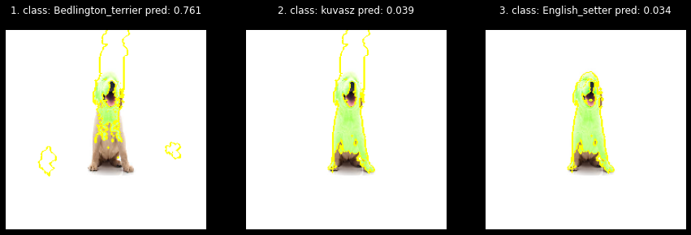

```python
plot_lime_top_explanations(model, "labrador2.jpg")
```

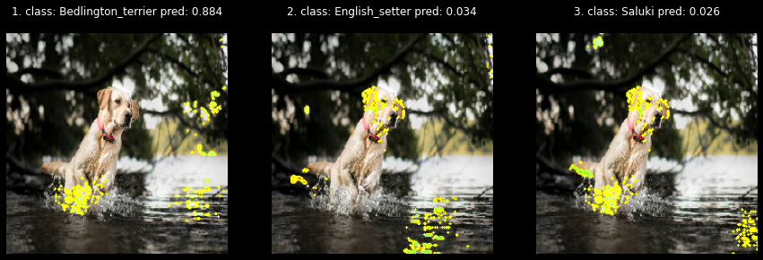

```python
plot_lime_top_explanations(model, "labrador7.jpg")
```

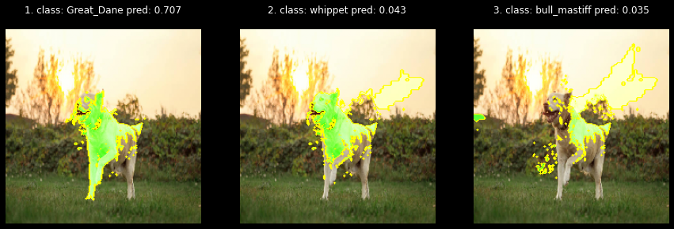

```python
plot_lime_top_explanations(model, "labrador8.jpg")
```

## Wnioski

Młody szczeniak taki jak na zdjęciu "labrador2.jpg" został najprawdopdobniej źle sklasywfiowany ze względu na to, że jak u większości innych zwierząt, tak również u psów proporcje ciała oraz 'tekstura' futra różni się od tego u osobnika dorosłego. Dla porównania na zdjęciu "labrador3.jpg" mimo tego, że pies również jest młody to widać że kształtem głowy i uszu jest podobny do dorosłego psa. Po analizie w GRAD-Camie można stwierdzić że u labradorów sieć upodobała sobie najbardziej ich uszy i okolice oczu. Z tego względu psy, które na zdjęciu biegną, skaczą lub generalnie są w ruchu znacząco ciężej się klasyfikuje. Analiza zdjęcia "labrador7.jpg" pokazuje, że sieć była skupiona na rozpryskach wody i mokreym futrze co zaoowocowało złą klasyfikacją.